# Estructuras de datos en

## Indexación de listas

Para indexar los elementos de una lista utilizaremos normalmente dobles corchetes `[[ ]]`. También es posible utilizar corchetes simples `[ ]` el igual que en los vectores atómicos. La diferencia entre las dos operaciones radica en el tipo de objeto que devuelve la selección:

- Con **dobles corchetes** obtendremos un objeto de la clase del elemento ubicado en dicha posición.
- Con **corchetes simples R** devolverá una lista con el objeto ubicado en dicha posición.

También se puede utilizar el **operador** `$` para obtener el mismo resultado que con los dobles corchetes.

Cuando se trabaja con listas, la mayoría de las veces emplearemos dobles corchetes `[[ ]]` o `$`, evitando utilizar corchetes simples `[ ]`.

Por lo demás, la selección de elementos funciona como en el resto de objetos de R que hemos visto hasta ahora.

```r
###################################
# Listas: Indexación              #
###################################

# Selección por índice
l2[2] #Devuelve una lista
l2[[2]] #Devuelve una matriz
```

**$df** =

|  | mpg | cyl | disp | hp | drat | wt | qsec | vs | am | gear | carb |
| --- | --- | --- | --- | --- | --- | --- | --- | --- | --- | --- | --- |
| Mazda RX4 | 21.0 | 6 | 160.0 | 110 | 3.90 | 2.620 | 16.46 | 0 | 1 | 4 | 4 |
| Mazda RX4 Wag | 21.0 | 6 | 160.0 | 110 | 3.90 | 2.875 | 17.02 | 0 | 1 | 4 | 4 |
| Datsun 710 | 22.8 | 4 | 108.0 | 93 | 3.85 | 2.320 | 18.61 | 1 | 1 | 4 | 1 |
| Hornet 4 Drive | 21.4 | 6 | 258.0 | 110 | 3.08 | 3.215 | 19.44 | 1 | 0 | 3 | 1 |
| Hornet Sportabout | 18.7 | 8 | 360.0 | 175 | 3.15 | 3.440 | 17.02 | 0 | 0 | 3 | 2 |
| Valiant | 18.1 | 6 | 225.0 | 105 | 2.76 | 3.460 | 20.22 | 1 | 0 | 3 | 1 |
| Duster 360 | 14.3 | 8 | 360.0 | 245 | 3.21 | 3.570 | 15.84 | 0 | 0 | 3 | 4 |
| Merc 240D | 24.4 | 4 | 146.7 | 62 | 3.69 | 3.190 | 20.00 | 1 | 0 | 4 | 2 |
| Merc 230 | 22.8 | 4 | 140.8 | 95 | 3.92 | 3.150 | 22.90 | 1 | 0 | 4 | 2 |
| Merc 280 | 19.2 | 6 | 167.6 | 123 | 3.92 | 3.440 | 18.30 | 1 | 0 | 4 | 4 |

|  | mpg | cyl | disp | hp | drat | wt | qsec | vs | am | gear | carb |
| --- | --- | --- | --- | --- | --- | --- | --- | --- | --- | --- | --- |
| Mazda RX4 | 21.0 | 6 | 160.0 | 110 | 3.90 | 2.620 | 16.46 | 0 | 1 | 4 | 4 |
| Mazda RX4 Wag | 21.0 | 6 | 160.0 | 110 | 3.90 | 2.875 | 17.02 | 0 | 1 | 4 | 4 |
| Datsun 710 | 22.8 | 4 | 108.0 | 93 | 3.85 | 2.320 | 18.61 | 1 | 1 | 4 | 1 |
| Hornet 4 Drive | 21.4 | 6 | 258.0 | 110 | 3.08 | 3.215 | 19.44 | 1 | 0 | 3 | 1 |
| Hornet Sportabout | 18.7 | 8 | 360.0 | 175 | 3.15 | 3.440 | 17.02 | 0 | 0 | 3 | 2 |
| Valiant | 18.1 | 6 | 225.0 | 105 | 2.76 | 3.460 | 20.22 | 1 | 0 | 3 | 1 |
| Duster 360 | 14.3 | 8 | 360.0 | 245 | 3.21 | 3.570 | 15.84 | 0 | 0 | 3 | 4 |
| Merc 240D | 24.4 | 4 | 146.7 | 62 | 3.69 | 3.190 | 20.00 | 1 | 0 | 4 | 2 |
| Merc 230 | 22.8 | 4 | 140.8 | 95 | 3.92 | 3.150 | 22.90 | 1 | 0 | 4 | 2 |
| Merc 280 | 19.2 | 6 | 167.6 | 123 | 3.92 | 3.440 | 18.30 | 1 | 0 | 4 | 4 |

```r
class(l2[2])
class(l2[[2]])
```

'list'

'data.frame'

```r
# Selección por nombre
l2[["mat"]] #Devuelve una matriz
l2$"mat" #Devuelve una matriz
l2["mat"] # Devuelve una lista
```

```
$<NA>
NULL
```

```r
l2[["mat"]][1, ] #Selecciona la primera fila de la matriz
l2[["vec"]][3] #Selecciona el tercer elmento del vector
```

3

## Información sobre listas

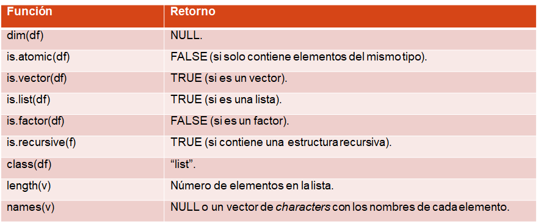

## Ejercicio 6

```r
###################################
# Listas                          #
###################################

actors <- c("Jack Nicholson", "Shelley Duvall", "Danny Lloyd", "Scatman Crothers", "Barry Nelson")
scores <- c(4.5, 4.0, 5.0)
sources <- c("IMDb1", "IMDb2", "IMDb3")
comments <- c("Best Horror Film I Have Ever Seen", "A truly brilliant and scary film from Stanley Kubrick", "A masterpiece of psychological horror")
reviews <- data.frame(scores, sources, comments)

# Crea una lista que contenga los siguientes componentes:
#   1. moviename: "The Shining"
#   2. actors: el vector de actores
#   3. reviews: el data frame de revbiews
shining_list <- list(moviename = "The Shining", actors = actors, reviews = reviews)

# Selecciona el último actor del vector de actores de la lista
last_actor <- shining_list[["actors"]][5]

# Selecciona la segunda de las críticas del data frame de reviews de la lista
second_review <- shining_list[["reviews"]][2, ]

# Añade un nuevo elemento a lista:
#   1. year: 1980
shining_list_full <- c(shining_list, year = 1980)

# Comprueba el contenido de la lista empleando la función str
str(shining_list_full)
```

```
List of 4
 $ moviename: chr "The Shining"
 $ actors   : chr [1:5] "Jack Nicholson" "Shelley Duvall" "Danny Lloyd" "Scatman Crothers" ...
 $ reviews  :'data.frame':	3 obs. of  3 variables:
  ..$ scores  : num [1:3] 4.5 4 5
  ..$ sources : Factor w/ 3 levels "IMDb1","IMDb2",..: 1 2 3
  ..$ comments: Factor w/ 3 levels "A masterpiece of psychological horror",..: 3 2 1
 $ year     : num 1980
```

## Resumen de objetos en R

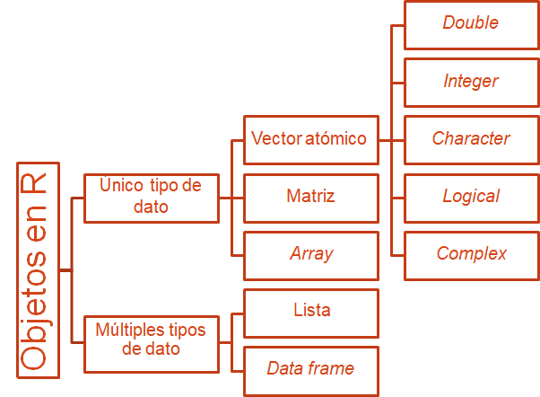